# Hello!

### Today:

1. You can still take notes in `ML/readme .md`
2. Finishing `ML_worksheet1.ipynb`
   - Last class: `ColumnTransformer` and `pipelines`, `fit` and `predict`
   - Today: `cross_validate` and `gridsearch_cv`
3. `ML_worksheet2.ipynb`: Classification models
   - How to evaluate them
   - Fixing our bad model
   - Thinking about the objective: what to maximize and/or minimize in your model

## Summary so far of skills

1. Splitting off the holdout sample: If data evolves over time, break off the latest 10-20% of date. Else, `test_train_split()`
2. Build a pipeline with steps for data preprocessing and an estimation method (`ColumnTransformer` and `pipelines`). Example:

   ```
   preproc_pipe = make_column_transformer(
       (make_pipeline(SimpleImputer(strategy="mean"),
                     StandardScaler()),
                     ["annual_inc", "int_rate"]),
       (make_pipeline(OneHotEncoder()), ["grade"]),
       remainder="drop",
   )
   ```

3. ABCD: See what the preprocessor does: `X_df_after_clean = df_after_transform(preproc_pipe,X_train)`
4. **Basic** use of that pipeline:

   ```
   pipeline_obj.fit(X_train,y_train)
   y_pred = pipeline_objy_prediction.predict(X_train)
   print(f'accuracy: {100*(y_pred == y_train)}')
   ```

5. Estimate performance: `cross_validate(pipeline_obj,X_train, y_train)` (and examine output)

## Next skill: Trying many models via `gridsearchCV`

`gridsearchCV` is just convenient for-loop: It runs `cross_validate` for as many pipeline objects as you ask, and it saves the results into an object you can examine and use.

**In Worksheet1, I will explain** how to use `gridsearchCV` to retry our logit model with many values of the logit parameter `C`.

GridsearchCV is very flexible: It can help you loop over so many possibilities! We will see this when we get to Worksheet3 (but not yet!).

## Classification models

- A **classification model** is when you're predicting an outcome with discrete levels and [is best divided into two parts:](https://scikit-learn.org/stable/modules/classification_threshold.html#)
  1. the statistical problem of learning a model to predict, ideally, class probabilities;
  2. the decision problem to take concrete action based on those probability predictions.
- Our current example:
  1. Step 1: Estimate via logit the probability of a loan charge off based on application data X.
  2. The fitted logit model produces, for a given vector of data X, the predicted probability that y=1 (charge off) for those values of X.
  3. This is not a classification, its a probability, a number in [0,1].
  4. Step 2: A *classification model that uses logit* takes the logit predicted probability, and outputs a prediction: YES, or NO.
- The considerations we learn in this application here apply to many settings: **Predicting what stocks to buy/sell is a two part problem as well**
  1. Estimate $f()$ to model a stock's future return: $ret_{t+1}=f(X_t)$
  2. Apply $f()$ to the latest data to generate predicted returns for all stocks, and then pick which stocks to buy and/or sell.

## Evaluating the classification model

First, we cover the classic "ML" model evaluation outputs. These aren't made for business settings, but are useful.

1. Calibration display
2. Classification report
3. Confusion Matrix
4. Precision-Recall Curve: Can your model have high recall and precision if we adjust the threshold?
5. ROC Curve: Can your model have low false positives and high recall if we adjust the threshold?

## Calibration display

To understand if our model is producing well-tuned probabilities (Step 1 of the 2 steps): **Calibration Display**

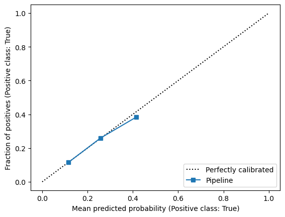

## Classification report

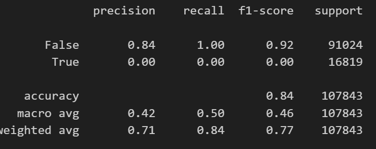

- False (paid back) precision: When our model predicts a loan will be paid back, how many actually were? (84%)
- False (paid back) recall: What fraction of the paid off loans does our model predict would be? (100%)

## Confusion Matrix

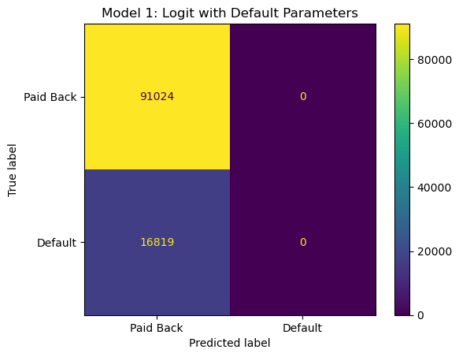

- Logit is decently calibrated
- But never predicts default --> bad precision and recall!

## Decision functions: Precision-Recall Curves

Let's go look at the worksheet for more details.

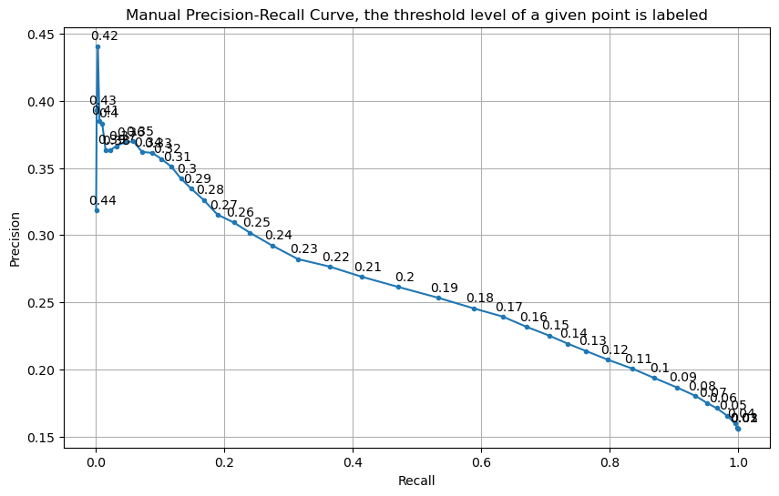

## Imbalanced data makes classification harder

- It makes the second step (turn logit predicted probs into binary predictions) hard
- Options:
  1. Manually pick a different threshold. If the predicted probablity is above X%, predict the outcome is positive. The default is 50%.
  2. Change estimator to "weight" groups equally (`class-weight=’balanced’` in tree models and logit... equiv to "oversampling")
  3. Remove data (meaning: undersample overrepresented group)
  4. Add data (meaning: oversample underrepresented group)

Let's see the first two options in the worksheet, adn then move to exercises

## Q1

*For these questions, assume your bank uses automated underwriting: If the model says you'll pay back the loan, they make the loan. Make extra (reasonable) assumptions as needed to compare the two models:*

**How much money does M2 save us relative to M1 from reduced charge-offs?**

## Q2

*For these questions, assume your bank uses automated underwriting: If the model says you'll pay back the loan, they make the loan. Make extra (reasonable) assumptions as needed to compare the two models:*

**How much foregone profit does M2 have relative to M1?**

## Q3

*For these questions, assume your bank uses automated underwriting: If the model says you'll pay back the loan, they make the loan. Make extra (reasonable) assumptions as needed to compare the two models:*

**Would you rather use M1 or M2 at your bank and why?**